# Corona in the states of America and in the provinces in The Netherlands

Now we do the same thing but we use instead of the confirmed cases the amount of deaths due to Corona per state, so the death rate. We will create figure C and figure D, again we use the same data in both figures, but we transform in figure D the X-axis to a logarithmic scale with base 10.

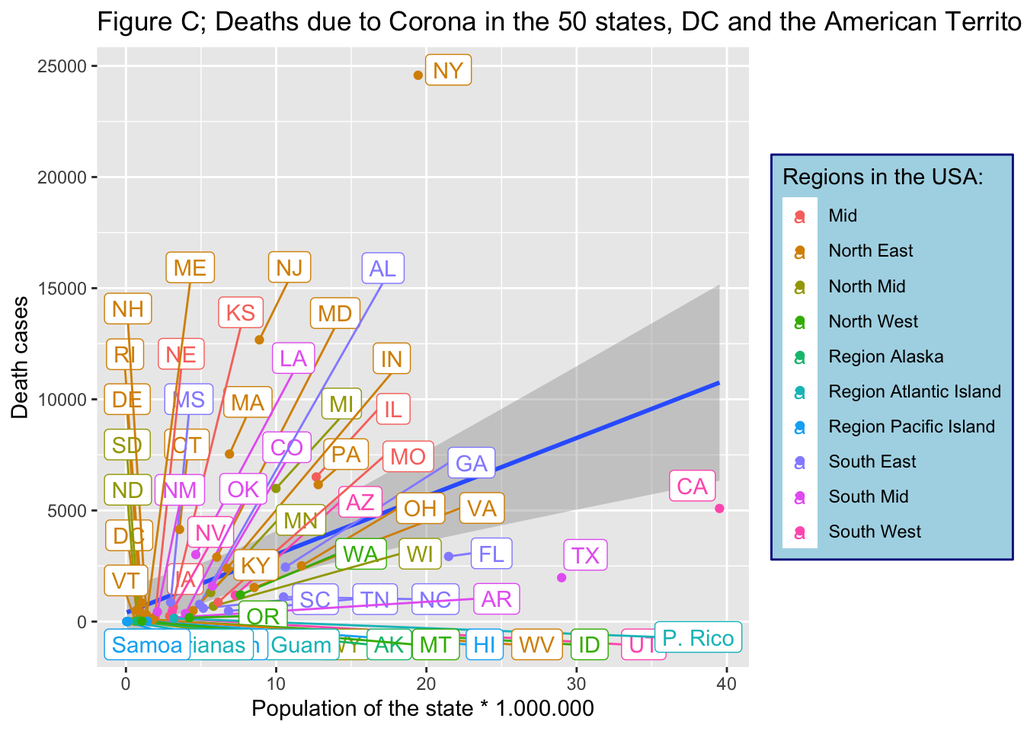

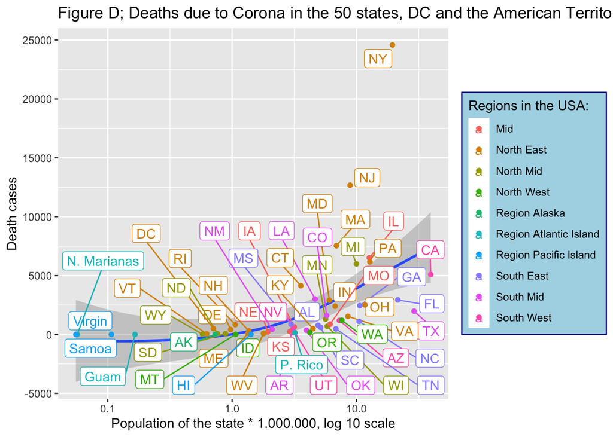

Again we look at the outliers compared to the ‘normal area’ on both sides. To determine the actual outliers I am going to ignore the outliers that are almost in the ‘normal area’. When we do this we will get the actual outliers with a high death rate New York (NY), New Jersey (NJ), Massachusetts (MA), Pennsylvania (PA), Illinios (IL) and Michigan (Mi). Again New York has an extremely high death rate and no other state is near New York. The real outliers with a lower death rate Tennessee (TN), Oregon (OR), North Carolina (NC) and Texas (TX) and Florida (FL). We see again that the north eastern states have a high death rate and that the south eastern states have a low death rate.

Now we are going to look at The Netherlands. The RIVM, the official institute that published the official data, provides also data about the Corona patients on the Intensive Care (IC), the hospital cases. We are going to create the same figures but this time for The Netherlands, and also the figures with the hospital cases. First we will create figure E, with normal scales on the axis and about the confirmed cases. Figure F is also about that data, but this time with a logarithmic X-scale.

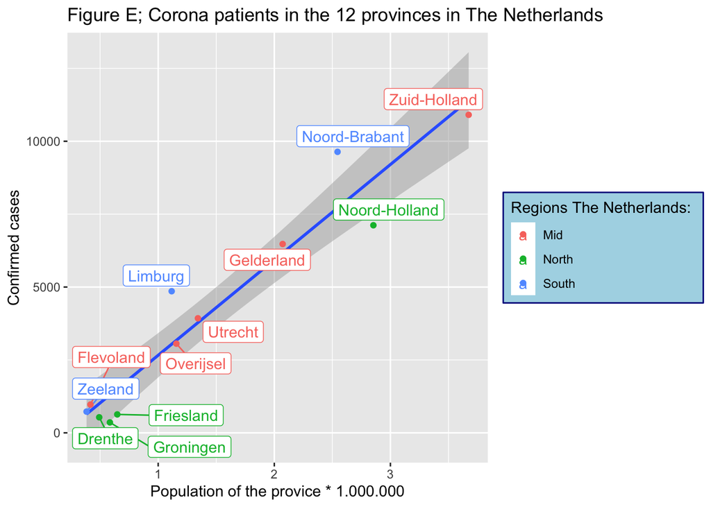

We see a big difference with the United States of America. Some states in the USA are located far away from the ‘normal area’, every province in the Netherlands are located in, or near the ‘normal area’. The only provinces outside that area are Noord-Holland with a slightly lower confirmed rate, and Limburg and Noord-Brabant with a slightly higher confirmed rate. When you look at the regions it is clear the the southern provinces has high confirmed rates, the provinces in the middle are not only in the area, but located on the line and the northern provinces have low confirmed rates.

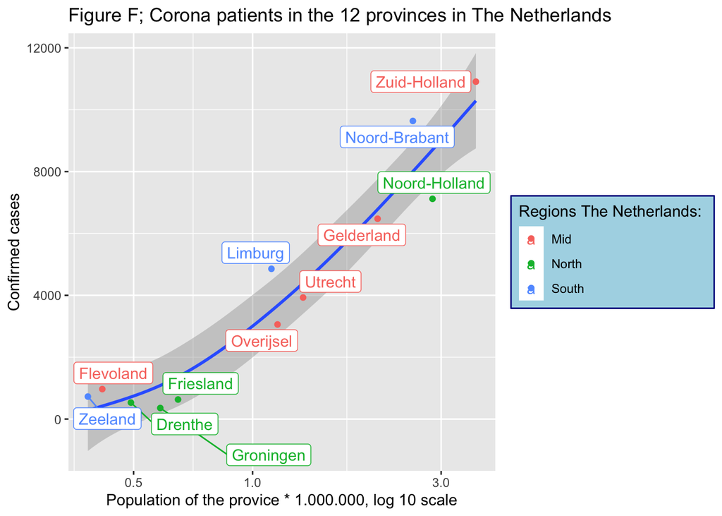

We see the same outliers in both figures, Limburg and Noord-Brabant with a higher confirmed rate, and Noord-Holland with a lower confirmed rate. We see again that the southern provinces have high rates, the provinces in the middle around around the line and in the area, and that the northern provinces have low rates when it comes to confirmed cases.